# Assignment1_Hints

Shehnaz

12/02/2020

# 1 Task 1

## 1.1 1.c Make an R function called mycoin()

### 1.1.1 1.c.i, ii. Matrix and totals

The ultimate goal is to construct a Bayes’ box or table, similar to that of lab 4, however, the arguments we pass in mycoin() will be: p, prior, n, x, alpha. The generated Bayes’ Box (matrix) will have 5 columns namely, p, prior, liklihood, h, posterior. (The below is just for better understanding of what goes in the matrix, please ignore the format)

P | Prior | Liklihood | h | Posterior |

- You may construct this using the matrix() function.
- To include the totals, we can use colSums() functions and append it to the table using rbind() function.

### 1.1.2 1.c.iv. Posterior Mean: Bayesian Point Estimate

$$p(\theta|x) = {\sum_{i=1}\theta_i p(\theta_i|x)}$$

As in the above expression, posterior mean can be calculated by summing the product of p and posterior from the Bayes’ table for example:

p=df$p

post=df$posterior

**postMean** = sum(p * post)

### 1.1.3 1.c.v. BCI

The Bayesian Credible Interval is just a central interval made from the posterior. So, a 95% bci will contain .95 of the area.

In order to compute the credible interval:

- first find the cumulative sum of posterior: cp = cumsum(posterior)
- Lower limit: L = max(which(cp<alpha/2))
- Upper limit: U = min(which(cp > 1-alpha/2))
- Now the get the interval from the ‘p’ column: **BCI** = df$p[c(L, U)]

### 1.1.5 1.c.xii.4 mycoin(p = seq(0,1,length=40), prior =pr, n=10, x=4, alpha = 0.05)

prior = function(l=40){

pr = c()

for (i in 1 to l)

```
pr= (i-l/2)^2
```

pr=pr/sum(pr)

#round pr to 4 dec places

}

pr = prior()

pr

# 2 Task 2

Lecture videos.

# 3 Task 3. Moment Generating Function(MGF)

$$M_X(t) = E(e^{Xt}) = \sum_xe^{Xt}p(x)$$
## 3.a and b. A very good resource for this derivation is here: https://www.le.ac.uk/users/dsgp1/COURSES/MATHSTAT/5binomgf.pdf

# 4 Task 4

## 4.1 4.a.b mynorm()

This is very similar to what we have done in Lab3 for mynormplot() function with an addition of ‘alpha’ in the argument.

mynorm = function(a, b, mu, sigma, alpha) {

1.Calculate a probability of the form (a<=x<=b) where X ~ N(mu, sigma) (Use pnorm() like lab3)

2.Make a plot of the normal curve within a suitable range.

3.Shade the area of interest

4.Round the area to 4 dec places and add a legend

#Quantiles

5.Compute q1 and q2 for ex: qnorm(p=alpha/2, mean=mu, sd=sigma) }

The plot looks something like this:

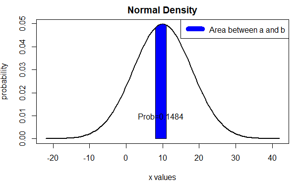

..

# 5 Task 5 Method of Maximum Likelihood

## 5.1 5.a. Joint distribution expression

Expressing the joint probability distribution as a product assuming independent trails.

P(X 1 ,X 2 ,…,X n ) =P(X 1 )P(X 2 ) ∗ ∗ ∗ P(X n )

## 5.2 5.b

The joint probability distribution becomes the likelihood function L(θ) L(θ) = P(θ 1 )P(θ 2 ) ∗ ∗ ∗ P(θ n )
$$L(\theta) = \Pi_{i=1}^{n} p(\theta_i)$$
Then

## 5.3 5.c, d

c.Taking the natural log of the likelihood function becomes the log likelihood function

$$l(\theta) = log(L(\theta))$$
d.The value of θˆ that renders a maximum value of the log likeliehood function becomes the maximum likelihood estimator

$$l'(\hat\theta) = 0 = \frac{d}{d\hat\theta}log(\Pi_{i=1}^{n} p(\hat\theta_i))$$
Now, for 5.e.1.

### 5.3.1 5.e.1. For $\hat\lambda$

To see if θˆ is the max estimator (Notice that we are deriving the function twice.)

$$l''(\hat\theta) = \frac{d^2}{d\hat\theta^2}log(\Pi_{i=1}^{n} p(\hat\theta_i)) < 0$$

https://newonlinecourses.science.psu.edu/stat414/node/191/ . Refer this link for further clarification. As we are finding the maximum likelihood estimator 𝜆ˆ using probability density function for the Poisson distribution:

$$f(x) = \frac{\lambda^xe^{-\lambda}}{x!}$$
Hence start with
$$L(\lambda) = \Pi_{i=1}^{n}\frac{\lambda^{x_i}e^{-\lambda}}{x_i!}$$
Then Obtain:
$$l(\lambda) = log (\Pi_{i=1}^{n}\frac{\lambda^{x_i}e^{-\lambda}}{x_i!})$$
Finally get $\hat\lambda$ by solving $\frac{dl(\lambda)}{d\lambda}=0$ Then

### 5.3.2 5.e.2: Second derivative of l(lambda),

$\frac{d^2l(\lambda)}{d\lambda^2}$

solve

### 5.3.3 5.e.3:

Show that this second derivative is < 0. (Note: Use to fact that log is a monotonically increasing function to justify your answer).

Alternatively, to prove λˆ is indeed maximum we need to show second derivative of l(λ) is negative when evaluated at λ = mean ($\bar x$).

### 5.3.4 5.e.4 and 5:

Show that the maximum of L(θ) is equal to the maximum of l(θ) Construct the function myml(), plot L(θ) and l(θ) to show that the max of both is same. You must also, show with a derivation along with the plot.

myml = function(x) { # Create lambda vector as a set of values ranging from 0 to 2*max(x)

lambda=seq(.01,2*max(x),0.5)

# Calculate Poisson MLE

lambdahat = round(sum(x)/length(x),4)

#the likelihood function

lik <- exp(-length(x)* lambda)*(lambda^sum(x))/prod(factorial(x))

#the loglikelihood function

loglik <- -length(x)* lambda+sum(x)*log(lambda)+log(prod(factorial(x)))

}

Plots will look like:

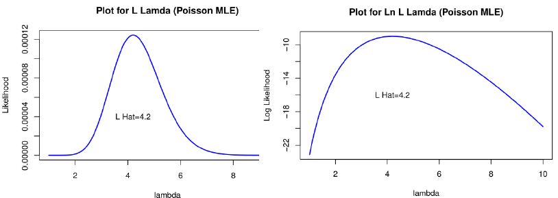

..

# 6 Task 6: Decide whether lambda hat is unbiased or not

From results above we found $\bar\lambda = \bar x$,the sample mean. We need to prove E(x) = λ.

Start with proving for a random variable Y ∼ Poisson(λ), E(Y ) = λ

# 7 Task 7: MLE for Bernoulli

Hint: Consider n Bernoulli trials with X successes.

$$p(x)\ =\ {n \choose X}\theta^X(1-\theta)^{n-X}$$
Compute the liklihood: $L(\theta)$

$$L(\theta)\ =\ {n \choose X}\theta^X(1-\theta)^{n-X}$$
Find the log(liklihood)

Then, Find the derivative of log(liklihood) and set it to 0.

Please see https://daviddalpiaz.github.io/stat3202-sp19/homework/pp-03-soln.pdf –> Exercise 9 for reference.

# 8 Task 8: mynr()

mynr = function (f, fdash, x0){} Uses the Newton-Raphson method to calculate a root. As inputs, it requires a function to be passed, a derivative to be passed, an initial guess, a tolerance, and a maximum number of iterations. https://rpubs.com/aaronsc32/newton-raphson-method

Expected Answer:

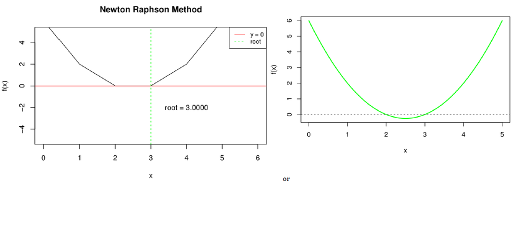

..

# 9 Task 9

Note: This is an incomplete code for reference with complete logic, you may modify it as you feel appropriate.

mynrml <- function(x, x0, tol = 1e-7, N = 100, dec = 6, a = 0, b = 10) {

loglikdash <- function(lambda, arg = x) {

```
(1/lambda)*sum(data) - length(data)
```

}

loglikdbldash <- function(lambda, arg = x) {

```
(-1/(lambda^2))*sum(data)
```

}

#the plot

curve(loglikdash, col = "“, lwd = 2, xlim = c(a,b), ylim = c(-5,10), xlab =”theta“, ylab =”“, main =”")

#Use the newton raphson method

#First initialize k to 0, the vector containing each iteration, i, the count of iterations, and x1.

k <- vector(mode = , length = )

i <- 1

x1 <- x0

#implement the loop

while (i is less than N) {

```
x1 <- x0 - (loglikdash(lambda = x0) / loglikedbldash(lambda = x0))
```

#Store each iterating in k

k[i] <- x1

#If the sequence of x_i’s converges, i.e. the distance between x_i and x_i+1 is below the pre-specified tolerance level, the loop ends

if (abs(x1 - x0) < tol) {

```
root <- k[length(k)]

out <- list("you know what goes here")

return(out)
```

} #if the loop isn’t ready to end, iterate

i <- i+1

x0 <- x1 }

#If the loop doesn’t end after N iterations, it stops

}

Now, call your mynrml() function with the given data.

# 10 TAsk 10

Need to re run the mynr() and eleminate fdash by approximating the derivative with $f'(x) \approx \frac{f(x+h)-f(x)}{h}$, where $h = 1*10^{-7}$.

mynrf <- function(f, x0, h = 1e-7, tol = 1e-7, N = 100, dec = 6, a = -7, b = 7) {

#Make the plot

curve(f, col = ’‘, lwd = 2, xlim=c(a, b), ylim=c(-5,10), xlab = ’x’, ylab=‘f(x)’, main = "") abline(h=0, lty = 5)

#Use the newton raphson method

#Initialize k to 0, the vector of iterations see task 9 hint

k <- vector()

i <- 1

x1 <- x0

while (i is less than N) {

```
df.dx <- (f(x0 + h) - f(x0))/h

x1 <- x0 - (f(x0) / df.dx)       #Finding the next x_i

k[i] <- x1                       #Storing x_i

i <- i + 1

if (abs(x1 - x0) < tol) {

  root <- k[]   #Store that length of k as root

  out <- list()

  return(out)
}
```

x0 <- x1

}

}

Now use mynrf with $f(x) = x^2 - 5x + 6,\ x_0 = -5$ with 4 decimal places of accuracy.